# assessing coding profiles for MMP

Conducts RSA model comparisons and sorts parcels into groups with different *coding profiles*. Displays results.

# description

the **tdclust** model:
$$rank(\textbf{r}) \sim
\textbf{x}_{\text{targt}}\beta_{\text{targt}} +
\textbf{x}_{\text{distr}}\beta_{\text{samecongr}} +
\textbf{x}_{\text{samecongr}}\beta_{\text{samecongr}}$$

- rank transformed response variable
- coefficients standardized (betas)
- subjects as random effect for all inferential tests

```r
stats.subjs.tdic <- fread(
  here("out", "rsa", "stats", paste0("subjs_pro_bias_acc-only_mmp_pearson_residual_glm-tdclust.csv"))
  )
stats.subjs.tdic <- stats.subjs.tdic[is.analysis.group == TRUE & y == "rank", ]  ## EXCLUDE HELD OUT SUBJECTS!
stats.subjs.tdic <- stats.subjs.tdic[, "coef" := NULL]

params.interest <- c("target", "distractor", "conclust")

stats.subjs.tdic %<>% full_join(atlas.key$mmp, by = "roi")
```

# 1. **task coding analysis**: test each regressor against zero (baseline)

## code

```r
## get stats

stats.group.tdic <- stats.subjs.tdic %>%
  group_by(num.roi, model, param) %>%
  summarize(
    v    = wilcox.test(beta, alternative = "greater")$statistic,
    p    = wilcox.test(beta, alternative = "greater")$p.value,
    beta = tanh(mean(atanh(beta))),  ## must be last in this summarize()
  ) %>%
  mutate(p.fdr = p.adjust(p, method = "fdr"), p.holm = p.adjust(p, method = "holm")) %>%
  ungroup

# stats.group.tdic %<>% select(roi, community, param, v, p, beta, p.fdr, p.holm)
stats.group.tdic %<>% full_join(atlas.key$mmp, by = "num.roi") %>% as.data.table
```

## results

```r
rois.targt <- stats.group.tdic[param == "target" & p.fdr < 0.05, roi]
rois.distr <- stats.group.tdic[param == "distractor" & p.fdr < 0.05, roi]
rois.incon <- stats.group.tdic[param == "conclust" & p.fdr < 0.05, roi]
rois.congr <- stats.group.tdic[param == "congruency" & p.fdr < 0.05, roi]

keep.these.bois <- c("beta", "v", "p.fdr", "num.roi", "roi", "hemi")
stats.coding.targt <- stats.group.tdic[param == "target", ..keep.these.bois]
stats.coding.distr <- stats.group.tdic[param == "distractor", ..keep.these.bois]
stats.coding.incon <- stats.group.tdic[param == "conclust", ..keep.these.bois]
stats.coding.congr <- stats.group.tdic[param == "congruency", ..keep.these.bois]
```

### target (206 parcels)

#### unthresholded

These values represent a (standardized) contrast of within-group correlations (e.g., within **target** correlations) against between-group correlations (i.e., between items with no common target, distractor, or congruency status).

Betas

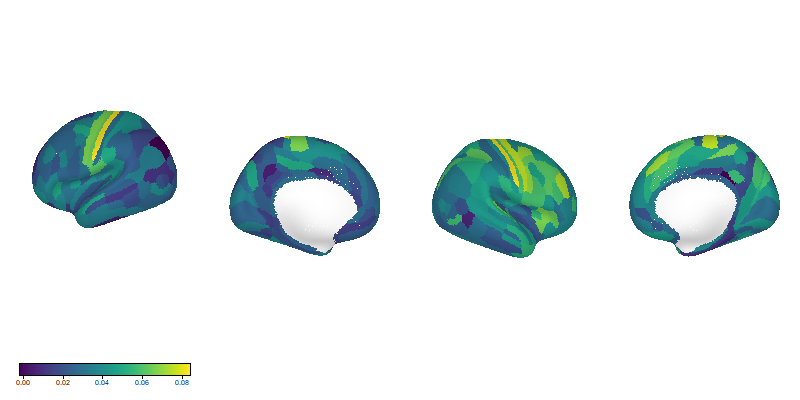

```r
stats.coding.targt %>% build_overlay("beta") %>% plot_surface(underlay = hcp)
```

Test statistics (sum of sign ranks)

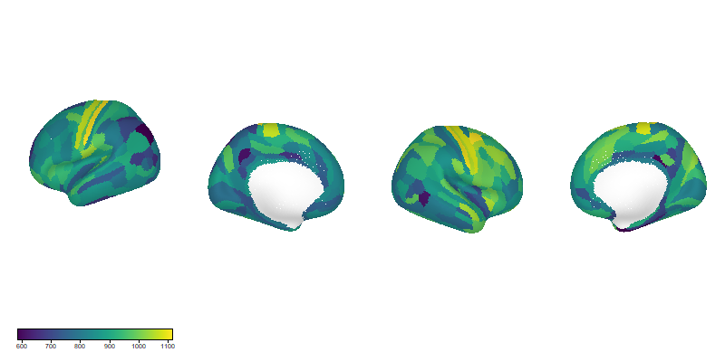

```r
stats.coding.targt %>% build_overlay("v") %>% plot_surface(underlay = hcp)
```

#### thresholded

Now thresholded at p < 0.05, FDR-corrected.

Betas

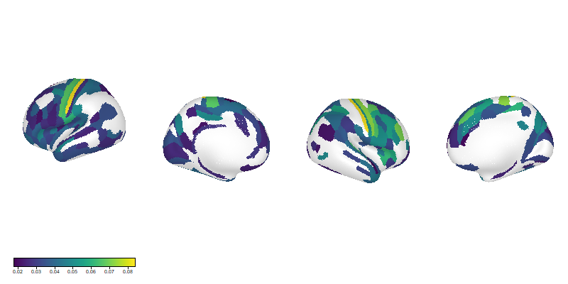

```r
stats.coding.targt %>%
  mutate(beta = ifelse(p.fdr < 0.05, beta, NA)) %>%
  build_overlay("beta") %>%
  plot_surface(underlay = hcp)
```

Test statistics (sum of sign ranks)

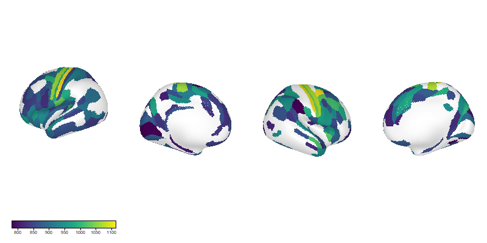

```r
stats.coding.targt %>%
  mutate(v = ifelse(p.fdr < 0.05, v, NA)) %>%
  build_overlay("v") %>%
  plot_surface(underlay = hcp)
```

#### table

Sorted (descending) by beta.

```r
kable(
  stats.group.tdic[param == "target" & p.fdr < 0.05] %>% arrange(-beta),
  digits = 2
)
```

| num.roi | model | param | v | p | beta | p.fdr | p.holm | roi | hemi | community | community.short |
| --- | --- | --- | --- | --- | --- | --- | --- | --- | --- | --- | --- |
| 9 | tdclust | target | 1113 | 0.00 | 0.08 | 0.00 | 0.00 | 3b_L | L | somatosensory and motor cortex | M1 and S1 |
| 8 | tdclust | target | 1065 | 0.00 | 0.07 | 0.00 | 0.00 | 4_L | L | somatosensory and motor cortex | M1 and S1 |
| 53 | tdclust | target | 985 | 0.00 | 0.06 | 0.00 | 0.00 | 3a_L | L | somatosensory and motor cortex | M1 and S1 |
| 189 | tdclust | target | 1049 | 0.00 | 0.06 | 0.00 | 0.00 | 3b_R | R | somatosensory and motor cortex | M1 and S1 |
| 100 | tdclust | target | 1037 | 0.00 | 0.06 | 0.00 | 0.00 | OP4_L | L | posterior opercular cortex | pOperc |
| 188 | tdclust | target | 1026 | 0.00 | 0.06 | 0.00 | 0.00 | 4_R | R | somatosensory and motor cortex | M1 and S1 |
| 263 | tdclust | target | 959 | 0.00 | 0.06 | 0.00 | 0.00 | p9-46v_R | R | dorsolateral prefrontal cortex | dlPFC |
| 190 | tdclust | target | 1056 | 0.00 | 0.05 | 0.00 | 0.00 | FEF_R | R | premotor cortex | PM |
| 243 | tdclust | target | 931 | 0.00 | 0.05 | 0.00 | 0.00 | 8BM_R | R | anterior cingulate and medial prefrontal cortex | aCC and mPFC |
| 236 | tdclust | target | 953 | 0.00 | 0.05 | 0.00 | 0.00 | 6v_R | R | premotor cortex | PM |
| 304 | tdclust | target | 934 | 0.00 | 0.05 | 0.00 | 0.00 | PBelt_R | R | early auditory cortex | early aud. |
| 170 | tdclust | target | 989 | 0.00 | 0.05 | 0.00 | 0.00 | p10p_L | L | orbital and polar frontal cortex | oFC and pFC |
| 288 | tdclust | target | 949 | 0.00 | 0.05 | 0.00 | 0.00 | FOP4_R | R | insular and frontal opercular cortex | insular and FO |
| 38 | tdclust | target | 949 | 0.00 | 0.05 | 0.00 | 0.00 | 23c_L | L | posterior cingulate cortex | pCC |
| 289 | tdclust | target | 992 | 0.00 | 0.05 | 0.00 | 0.00 | MI_R | R | insular and frontal opercular cortex | insular and FO |
| 12 | tdclust | target | 992 | 0.00 | 0.05 | 0.00 | 0.00 | 55b_L | L | premotor cortex | PM |
| 147 | tdclust | target | 981 | 0.00 | 0.05 | 0.00 | 0.00 | PFop_L | L | inferior parietal cortex | iP |
| 217 | tdclust | target | 963 | 0.00 | 0.05 | 0.00 | 0.00 | 5mv_R | R | paracentral lobular and mid cingulate cortex | PL and mid cing. |
| 326 | tdclust | target | 976 | 0.00 | 0.05 | 0.00 | 0.00 | IP0_R | R | inferior parietal cortex | iP |
| 169 | tdclust | target | 967 | 0.00 | 0.05 | 0.00 | 0.00 | FOP5_L | L | insular and frontal opercular cortex | insular and FO |
| 128 | tdclust | target | 943 | 0.00 | 0.05 | 0.00 | 0.00 | STSda_L | L | auditory association cortex | aud. assoc. |
| 174 | tdclust | target | 1012 | 0.00 | 0.05 | 0.00 | 0.00 | LBelt_L | L | early auditory cortex | early aud. |
| 15 | tdclust | target | 980 | 0.00 | 0.05 | 0.00 | 0.00 | POS2_L | L | posterior cingulate cortex | pCC |
| 349 | tdclust | target | 890 | 0.00 | 0.05 | 0.01 | 0.01 | FOP5_R | R | insular and frontal opercular cortex | insular and FO |
| 192 | tdclust | target | 995 | 0.00 | 0.05 | 0.00 | 0.00 | 55b_R | R | premotor cortex | PM |
| 297 | tdclust | target | 953 | 0.00 | 0.05 | 0.00 | 0.00 | AIP_R | R | superior parietal cortex | sP |
| 223 | tdclust | target | 948 | 0.00 | 0.05 | 0.00 | 0.00 | SCEF_R | R | paracentral lobular and mid cingulate cortex | PL and mid cing. |
| 259 | tdclust | target | 928 | 0.00 | 0.05 | 0.00 | 0.00 | IFJa_R | R | inferior frontal cortex | iFC |
| 224 | tdclust | target | 984 | 0.00 | 0.05 | 0.00 | 0.00 | 6ma_R | R | paracentral lobular and mid cingulate cortex | PL and mid cing. |
| 253 | tdclust | target | 982 | 0.00 | 0.05 | 0.00 | 0.00 | 8C_R | R | dorsolateral prefrontal cortex | dlPFC |

[output cut: 176 more lines]

### distractor (21 parcels)

#### unthresholded

Betas

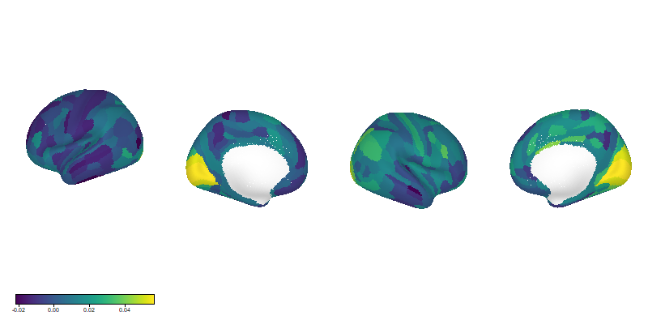

```r
stats.group.tdic[param == "distractor"] %>% build_overlay("beta") %>% plot_surface(underlay = hcp)
```

Test statistics (sum of sign ranks)

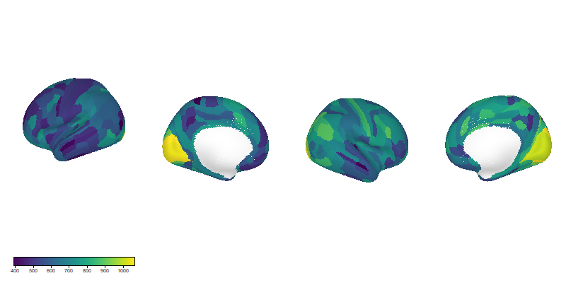

```r
stats.group.tdic[param == "distractor"] %>% build_overlay("v") %>% plot_surface(underlay = hcp)
```

#### thresholded

Betas

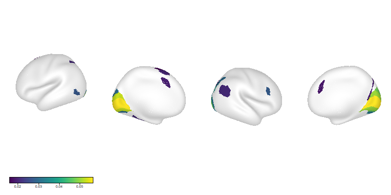

```r
stats.coding.distr %>%
  mutate(beta = ifelse(p.fdr < 0.05, beta, NA)) %>%
  build_overlay("beta") %>%
  plot_surface(underlay = hcp)
```

Test statistics (sum of sign ranks)

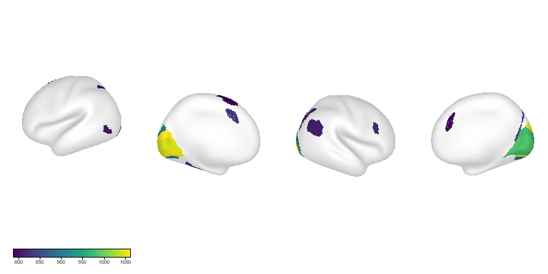

```r
stats.coding.distr %>%
  mutate(v = ifelse(p.fdr < 0.05, v, NA)) %>%
  build_overlay("v") %>%
  plot_surface(underlay = hcp)
```

#### table

Sorted (descending) by beta.

```r
kable(
  stats.group.tdic[param == "distractor" & p.fdr < 0.05] %>% arrange(-beta),
  digits = 2
)
```

| num.roi | model | param | v | p | beta | p.fdr | p.holm | roi | hemi | community | community.short |
| --- | --- | --- | --- | --- | --- | --- | --- | --- | --- | --- | --- |
| 1 | tdclust | distractor | 1046 | 0.00 | 0.06 | 0.00 | 0.00 | V1_L | L | primary visual cortex | V1 |
| 4 | tdclust | distractor | 1061 | 0.00 | 0.05 | 0.00 | 0.00 | V2_L | L | early visual cortex | early vis. |
| 181 | tdclust | distractor | 913 | 0.00 | 0.04 | 0.00 | 0.00 | V1_R | R | primary visual cortex | V1 |
| 184 | tdclust | distractor | 907 | 0.00 | 0.04 | 0.00 | 0.00 | V2_R | R | early visual cortex | early vis. |
| 185 | tdclust | distractor | 958 | 0.00 | 0.04 | 0.00 | 0.00 | V3_R | R | early visual cortex | early vis. |
| 5 | tdclust | distractor | 912 | 0.00 | 0.03 | 0.00 | 0.00 | V3_L | L | early visual cortex | early vis. |
| 326 | tdclust | distractor | 815 | 0.02 | 0.03 | 0.02 | 0.02 | IP0_R | R | inferior parietal cortex | iP |
| 157 | tdclust | distractor | 801 | 0.03 | 0.03 | 0.03 | 0.03 | FST_L | L | MT+ complex and neighbors | MT+ |
| 186 | tdclust | distractor | 857 | 0.01 | 0.03 | 0.02 | 0.02 | V4_R | R | early visual cortex | early vis. |
| 16 | tdclust | distractor | 825 | 0.02 | 0.03 | 0.03 | 0.03 | V7_L | L | dorsal stream visual cortex | d vis. |
| 325 | tdclust | distractor | 811 | 0.02 | 0.03 | 0.03 | 0.05 | IP1_R | R | inferior parietal cortex | iP |
| 259 | tdclust | distractor | 813 | 0.02 | 0.02 | 0.03 | 0.05 | IFJa_R | R | inferior frontal cortex | iFC |
| 127 | tdclust | distractor | 814 | 0.02 | 0.02 | 0.03 | 0.04 | PHA3_L | L | medial temporal cortex | mT |
| 95 | tdclust | distractor | 798 | 0.03 | 0.02 | 0.03 | 0.03 | LIPd_L | L | superior parietal cortex | sP |
| 26 | tdclust | distractor | 788 | 0.04 | 0.02 | 0.04 | 0.04 | SFL_L | L | dorsolateral prefrontal cortex | dlPFC |
| 330 | tdclust | distractor | 806 | 0.03 | 0.02 | 0.04 | 0.05 | PGi_R | R | inferior parietal cortex | iP |
| 60 | tdclust | distractor | 830 | 0.02 | 0.02 | 0.02 | 0.03 | p32pr_L | L | anterior cingulate and medial prefrontal cortex | aCC and mPFC |
| 322 | tdclust | distractor | 827 | 0.02 | 0.02 | 0.02 | 0.03 | DVT_R | R | posterior cingulate cortex | pCC |
| 359 | tdclust | distractor | 794 | 0.04 | 0.02 | 0.04 | 0.04 | a32pr_R | R | anterior cingulate and medial prefrontal cortex | aCC and mPFC |
| 197 | tdclust | distractor | 792 | 0.04 | 0.02 | 0.04 | 0.04 | IPS1_R | R | dorsal stream visual cortex | d vis. |
| 44 | tdclust | distractor | 787 | 0.04 | 0.02 | 0.05 | 0.08 | 6ma_L | L | paracentral lobular and mid cingulate cortex | PL and mid cing. |

### conclust (61 parcels)

#### unthresholded

Betas

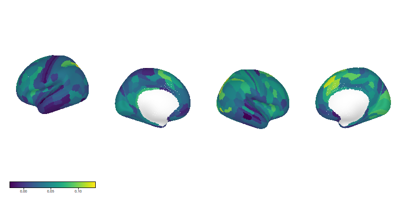

```r
stats.group.tdic[param == "conclust"] %>% build_overlay("beta") %>% plot_surface(underlay = hcp)
```

Test statistics (sum of sign ranks)

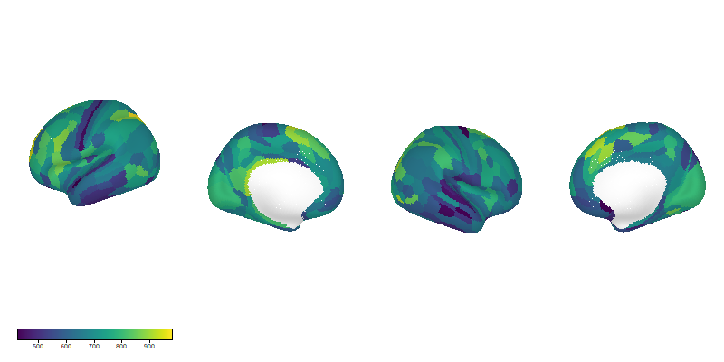

```r
stats.group.tdic[param == "conclust"] %>% build_overlay("v") %>% plot_surface(underlay = hcp)
```

#### thresholded

Betas

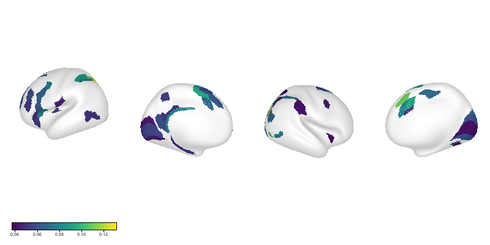

```r
stats.coding.incon %>%
  mutate(beta = ifelse(p.fdr < 0.05, beta, NA)) %>%
  build_overlay("beta") %>%
  plot_surface(underlay = hcp)
```

Test statistics (sum of sign ranks)

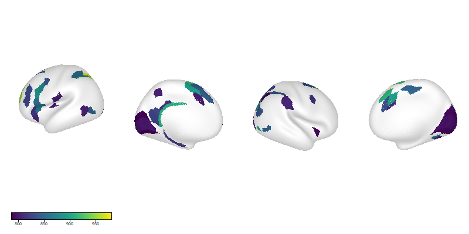

```r
stats.coding.incon %>%
  mutate(v = ifelse(p.fdr < 0.05, v, NA)) %>%
  build_overlay("v") %>%
  plot_surface(underlay = hcp)
```

#### table

Sorted (descending) by beta.

```r
kable(
  stats.group.tdic[param == "conclust" & p.fdr < 0.05] %>% arrange(-beta),
  digits = 2
)
```

| num.roi | model | param | v | p | beta | p.fdr | p.holm | roi | hemi | community | community.short |
| --- | --- | --- | --- | --- | --- | --- | --- | --- | --- | --- | --- |
| 145 | tdclust | conclust | 953 | 0.00 | 0.13 | 0.00 | 0.00 | IP1_L | L | inferior parietal cortex | iP |
| 50 | tdclust | conclust | 965 | 0.00 | 0.12 | 0.00 | 0.00 | MIP_L | L | superior parietal cortex | sP |
| 95 | tdclust | conclust | 980 | 0.00 | 0.11 | 0.00 | 0.00 | LIPd_L | L | superior parietal cortex | sP |
| 326 | tdclust | conclust | 921 | 0.00 | 0.09 | 0.00 | 0.00 | IP0_R | R | inferior parietal cortex | iP |
| 43 | tdclust | conclust | 895 | 0.00 | 0.09 | 0.00 | 0.00 | SCEF_L | L | paracentral lobular and mid cingulate cortex | PL and mid cing. |
| 117 | tdclust | conclust | 857 | 0.01 | 0.09 | 0.01 | 0.01 | AIP_L | L | superior parietal cortex | sP |
| 230 | tdclust | conclust | 861 | 0.01 | 0.09 | 0.02 | 0.02 | MIP_R | R | superior parietal cortex | sP |
| 243 | tdclust | conclust | 917 | 0.00 | 0.08 | 0.00 | 0.00 | 8BM_R | R | anterior cingulate and medial prefrontal cortex | aCC and mPFC |
| 44 | tdclust | conclust | 926 | 0.00 | 0.08 | 0.00 | 0.00 | 6ma_L | L | paracentral lobular and mid cingulate cortex | PL and mid cing. |
| 17 | tdclust | conclust | 893 | 0.00 | 0.08 | 0.01 | 0.01 | IPS1_L | L | dorsal stream visual cortex | d vis. |
| 201 | tdclust | conclust | 910 | 0.00 | 0.08 | 0.00 | 0.00 | LO2_R | R | MT+ complex and neighbors | MT+ |
| 278 | tdclust | conclust | 982 | 0.00 | 0.08 | 0.00 | 0.00 | s6-8_R | R | dorsolateral prefrontal cortex | dlPFC |
| 14 | tdclust | conclust | 909 | 0.00 | 0.08 | 0.00 | 0.00 | RSC_L | L | posterior cingulate cortex | pCC |
| 108 | tdclust | conclust | 864 | 0.01 | 0.08 | 0.01 | 0.01 | FOP4_L | L | insular and frontal opercular cortex | insular and FO |
| 144 | tdclust | conclust | 886 | 0.00 | 0.08 | 0.01 | 0.01 | IP2_L | L | inferior parietal cortex | iP |
| 11 | tdclust | conclust | 838 | 0.01 | 0.08 | 0.02 | 0.02 | PEF_L | L | premotor cortex | PM |
| 240 | tdclust | conclust | 903 | 0.00 | 0.08 | 0.00 | 0.00 | p32pr_R | R | anterior cingulate and medial prefrontal cortex | aCC and mPFC |
| 224 | tdclust | conclust | 925 | 0.00 | 0.07 | 0.00 | 0.00 | 6ma_R | R | paracentral lobular and mid cingulate cortex | PL and mid cing. |
| 197 | tdclust | conclust | 831 | 0.01 | 0.07 | 0.02 | 0.03 | IPS1_R | R | dorsal stream visual cortex | d vis. |
| 60 | tdclust | conclust | 800 | 0.03 | 0.07 | 0.03 | 0.03 | p32pr_L | L | anterior cingulate and medial prefrontal cortex | aCC and mPFC |
| 359 | tdclust | conclust | 843 | 0.01 | 0.07 | 0.02 | 0.02 | a32pr_R | R | anterior cingulate and medial prefrontal cortex | aCC and mPFC |
| 80 | tdclust | conclust | 879 | 0.00 | 0.07 | 0.01 | 0.01 | IFJp_L | L | inferior frontal cortex | iFC |
| 337 | tdclust | conclust | 857 | 0.01 | 0.07 | 0.01 | 0.01 | FST_R | R | MT+ complex and neighbors | MT+ |
| 79 | tdclust | conclust | 888 | 0.00 | 0.07 | 0.00 | 0.01 | IFJa_L | L | inferior frontal cortex | iFC |
| 97 | tdclust | conclust | 830 | 0.02 | 0.07 | 0.02 | 0.03 | i6-8_L | L | dorsolateral prefrontal cortex | dlPFC |
| 324 | tdclust | conclust | 848 | 0.01 | 0.07 | 0.01 | 0.02 | IP2_R | R | inferior parietal cortex | iP |
| 63 | tdclust | conclust | 844 | 0.01 | 0.06 | 0.02 | 0.03 | 8BM_L | L | anterior cingulate and medial prefrontal cortex | aCC and mPFC |
| 86 | tdclust | conclust | 951 | 0.00 | 0.06 | 0.00 | 0.00 | 9-46d_L | L | dorsolateral prefrontal cortex | dlPFC |
| 220 | tdclust | conclust | 857 | 0.01 | 0.06 | 0.01 | 0.01 | 24dd_R | R | paracentral lobular and mid cingulate cortex | PL and mid cing. |
| 323 | tdclust | conclust | 847 | 0.01 | 0.06 | 0.03 | 0.03 | PGp_R | R | inferior parietal cortex | iP |
| 185 | tdclust | conclust | 807 | 0.03 | 0.06 | 0.03 | 0.04 | V3_R | R | early visual cortex | early vis. |
| 74 | tdclust | conclust | 856 | 0.01 | 0.06 | 0.01 | 0.02 | 44_L | L | inferior frontal cortex | iFC |
| 83 | tdclust | conclust | 833 | 0.01 | 0.06 | 0.02 | 0.03 | p9-46v_L | L | dorsolateral prefrontal cortex | dlPFC |
| 31 | tdclust | conclust | 825 | 0.02 | 0.06 | 0.03 | 0.04 | POS1_L | L | posterior cingulate cortex | pCC |
| 184 | tdclust | conclust | 801 | 0.03 | 0.06 | 0.03 | 0.03 | V2_R | R | early visual cortex | early vis. |
| 199 | tdclust | conclust | 859 | 0.01 | 0.06 | 0.02 | 0.02 | V3B_R | R | dorsal stream visual cortex | d vis. |
| 26 | tdclust | conclust | 842 | 0.01 | 0.06 | 0.02 | 0.02 | SFL_L | L | dorsolateral prefrontal cortex | dlPFC |
| 276 | tdclust | conclust | 842 | 0.01 | 0.06 | 0.02 | 0.02 | 6a_R | R | premotor cortex | PM |
| 340 | tdclust | conclust | 869 | 0.01 | 0.06 | 0.02 | 0.02 | VMV2_R | R | ventral stream visual cortex | v vis. |
| 1 | tdclust | conclust | 798 | 0.03 | 0.06 | 0.05 | 0.07 | V1_L | L | primary visual cortex | V1 |
| 168 | tdclust | conclust | 799 | 0.03 | 0.05 | 0.05 | 0.06 | Ig_L | L | insular and frontal opercular cortex | insular and FO |
| 239 | tdclust | conclust | 821 | 0.02 | 0.05 | 0.03 | 0.04 | a24pr_R | R | anterior cingulate and medial prefrontal cortex | aCC and mPFC |
| 27 | tdclust | conclust | 804 | 0.03 | 0.05 | 0.04 | 0.07 | PCV_L | L | posterior cingulate cortex | pCC |
| 82 | tdclust | conclust | 825 | 0.02 | 0.05 | 0.03 | 0.03 | IFSa_L | L | inferior frontal cortex | iFC |
| 111 | tdclust | conclust | 808 | 0.03 | 0.05 | 0.04 | 0.05 | AVI_L | L | insular and frontal opercular cortex | insular and FO |
| 33 | tdclust | conclust | 830 | 0.02 | 0.05 | 0.05 | 0.05 | v23ab_L | L | posterior cingulate cortex | pCC |
| 137 | tdclust | conclust | 804 | 0.03 | 0.05 | 0.04 | 0.06 | PHT_L | L | lateral temporal cortex | lT |
| 34 | tdclust | conclust | 813 | 0.02 | 0.05 | 0.03 | 0.05 | d23ab_L | L | posterior cingulate cortex | pCC |
| 325 | tdclust | conclust | 797 | 0.03 | 0.05 | 0.03 | 0.05 | IP1_R | R | inferior parietal cortex | iP |
| 191 | tdclust | conclust | 825 | 0.02 | 0.05 | 0.03 | 0.03 | PEF_R | R | premotor cortex | PM |
| 157 | tdclust | conclust | 846 | 0.01 | 0.05 | 0.01 | 0.02 | FST_L | L | MT+ complex and neighbors | MT+ |
| 120 | tdclust | conclust | 817 | 0.02 | 0.05 | 0.04 | 0.06 | H_L | L | medial temporal cortex | mT |
| 169 | tdclust | conclust | 818 | 0.02 | 0.05 | 0.03 | 0.04 | FOP5_L | L | insular and frontal opercular cortex | insular and FO |
| 328 | tdclust | conclust | 817 | 0.02 | 0.05 | 0.04 | 0.06 | PF_R | R | inferior parietal cortex | iP |
| 181 | tdclust | conclust | 805 | 0.03 | 0.05 | 0.04 | 0.06 | V1_R | R | primary visual cortex | V1 |
| 228 | tdclust | conclust | 837 | 0.01 | 0.05 | 0.02 | 0.03 | LIPv_R | R | superior parietal cortex | sP |
| 289 | tdclust | conclust | 800 | 0.03 | 0.05 | 0.05 | 0.06 | MI_R | R | insular and frontal opercular cortex | insular and FO |
| 334 | tdclust | conclust | 811 | 0.02 | 0.05 | 0.04 | 0.05 | VMV3_R | R | ventral stream visual cortex | v vis. |
| 100 | tdclust | conclust | 802 | 0.03 | 0.05 | 0.04 | 0.06 | OP4_L | L | posterior opercular cortex | pOperc |
| 4 | tdclust | conclust | 786 | 0.04 | 0.04 | 0.04 | 0.04 | V2_L | L | early visual cortex | early vis. |
| 170 | tdclust | conclust | 801 | 0.03 | 0.04 | 0.05 | 0.06 | p10p_L | L | orbital and polar frontal cortex | oFC and pFC |

### intersections

```r
rois.targt.incon <- intersect(rois.targt, rois.incon)
rois.targt.distr <- intersect(rois.targt, rois.distr)
rois.distr.incon <- intersect(rois.distr, rois.incon)
rois.targt.distr.incon <- Reduce(intersect, list(rois.targt, rois.incon, rois.distr))

rois.targt.incon
```

```
##  [1] "V1_L"     "V2_L"     "PEF_L"    "RSC_L"    "SFL_L"    "PCV_L"
##  [7] "POS1_L"   "d23ab_L"  "SCEF_L"   "6ma_L"    "MIP_L"    "p32pr_L"
## [13] "8BM_L"    "44_L"     "IFJa_L"   "IFJp_L"   "IFSa_L"   "p9-46v_L"
## [19] "LIPd_L"   "i6-8_L"   "OP4_L"    "FOP4_L"   "AVI_L"    "AIP_L"
## [25] "H_L"      "PHT_L"    "IP1_L"    "FST_L"    "Ig_L"     "FOP5_L"
## [31] "p10p_L"   "V2_R"     "V3_R"     "PEF_R"    "IPS1_R"   "V3B_R"
## [37] "24dd_R"   "6ma_R"    "LIPv_R"   "MIP_R"    "a24pr_R"  "p32pr_R"
## [43] "8BM_R"    "6a_R"     "s6-8_R"   "MI_R"     "IP2_R"    "IP1_R"
## [49] "IP0_R"    "PF_R"     "VMV3_R"   "FST_R"    "VMV2_R"   "a32pr_R"
```

```r
rois.targt.distr
```

```
##  [1] "V1_L"    "V2_L"    "V3_L"    "V7_L"    "SFL_L"   "6ma_L"   "p32pr_L"
##  [8] "LIPd_L"  "PHA3_L"  "FST_L"   "V2_R"    "V3_R"    "IPS1_R"  "IFJa_R"
## [15] "DVT_R"   "IP1_R"   "IP0_R"   "PGi_R"   "a32pr_R"
```

```r
rois.distr.incon
```

```
##  [1] "V1_L"    "V2_L"    "SFL_L"   "6ma_L"   "p32pr_L" "LIPd_L"  "FST_L"
##  [8] "V1_R"    "V2_R"    "V3_R"    "IPS1_R"  "IP1_R"   "IP0_R"   "a32pr_R"
```

```r
rois.targt.distr.incon
```

```
##  [1] "V1_L"    "V2_L"    "SFL_L"   "6ma_L"   "p32pr_L" "LIPd_L"  "FST_L"
##  [8] "V2_R"    "V3_R"    "IPS1_R"  "IP1_R"   "IP0_R"   "a32pr_R"
```

# 2. **preference analysis**: pairwise comparisons

## code

- paired wilcoxon sign-rank test on estimated betas
  - 3 tests per parcel (t vs d, t vs i, d vs i)
  - two-sided
  - p-values FDR corrected across all comparisons, within each roi

```r
## get p vals

stats.pairs.tdic <- stats.subjs.tdic %>%
  filter(param %in% params.interest) %>%
  group_by(roi) %>%
  summarize(
    out = list(
      pairwise.wilcox.test(beta, param, paired = TRUE, alternative = "two.sided", p.adjust.method = "fdr")
    )
  )
pvals <- vapply(stats.pairs.tdic$out, function(.) .$p.value[lower.tri(diag(2), diag = TRUE)], numeric(3))
pvals <- t(pvals)
colnames(pvals) <- c("p.incon.distr", "p.targt.distr", "p.targt.incon")
stats.pairs.tdic <- data.frame(roi = stats.pairs.tdic$roi, pvals, stringsAsFactors = FALSE)

## get mean diffs

stats.pairs.tdic %<>% full_join(
  stats.subjs.tdic %>%
    filter(param %in% params.interest) %>%
    group_by(roi) %>%
    summarize(
      b.incon.distr = tanh(mean(atanh(beta[param == "conclust"]) - atanh(beta[param == "distractor"]))),
      b.targt.distr = tanh(mean(atanh(beta[param == "target"]) - atanh(beta[param == "distractor"]))),
      b.targt.incon = tanh(mean(atanh(beta[param == "target"]) - atanh(beta[param == "conclust"]))),
    ),
  by = "roi"
)

stats.pairs.tdic %<>% full_join(atlas.key$mmp, by = "roi") %>% as.data.table
```

## results

```r
rois.pref.targt.vs.distr <- stats.pairs.tdic[roi %in% rois.targt & p.targt.distr < 0.05 & b.targt.distr > 0, roi]
rois.pref.targt.vs.incon <- stats.pairs.tdic[roi %in% rois.targt & p.targt.incon < 0.05 & b.targt.incon > 0, roi]

rois.pref.distr.vs.targt <- stats.pairs.tdic[roi %in% rois.distr & p.targt.distr < 0.05 & b.targt.distr < 0, roi]
rois.pref.distr.vs.incon <- stats.pairs.tdic[roi %in% rois.distr & b.incon.distr < 0.05 & b.incon.distr < 0, roi]

rois.pref.incon.vs.distr <- stats.pairs.tdic[roi %in% rois.incon & b.incon.distr < 0.05 & b.incon.distr > 0, roi]
rois.pref.incon.vs.targt <- stats.pairs.tdic[roi %in% rois.incon & p.targt.incon < 0.05 & b.targt.incon < 0, roi]

rois.pref.targt <- intersect(rois.pref.targt.vs.incon, rois.pref.targt.vs.distr)
rois.pref.distr <- intersect(rois.pref.distr.vs.targt, rois.pref.distr.vs.incon)
rois.pref.incon <- intersect(rois.pref.incon.vs.targt, rois.pref.incon.vs.distr)
```

Of the task coding parcels, which show preferece for certain task dimensions over others? In this section, each task dimension is considered in turn. ROIs are identified in each subsection that meet criteria for having certain representational ‘preferences’. Within each subsection, these criteria get progressively more stringent.

### target

#### target > {distractor, 0} (23 parcels)

Betas

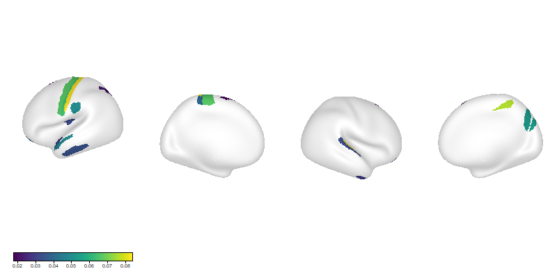

```r
stats.coding.targt %>%
  mutate(beta = ifelse(roi %in% rois.pref.targt.vs.distr, beta, NA)) %>%
  build_overlay("beta") %>%
  plot_surface(underlay = hcp)
```

Test statistics (sum of sign ranks)

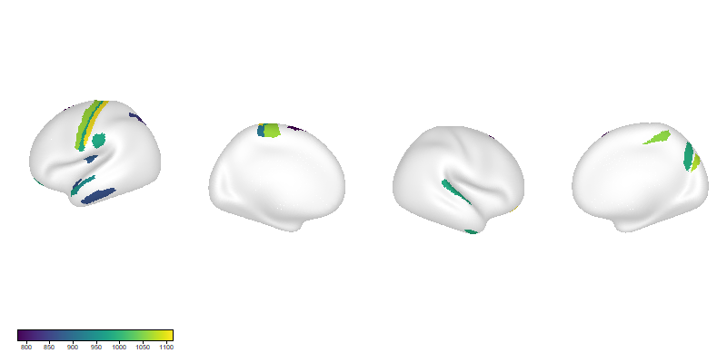

```r
stats.coding.targt %>%
  mutate(v = ifelse(roi %in% rois.pref.targt.vs.distr, v, NA)) %>%
  build_overlay("v") %>%
  plot_surface(underlay = hcp)
```

```r
kable(
  stats.pairs.tdic[roi %in% rois.pref.targt.vs.distr] %>% arrange(-b.targt.distr),
  digits = 2
  )
```

| roi | p.incon.distr | p.targt.distr | p.targt.incon | b.incon.distr | b.targt.distr | b.targt.incon | num.roi | hemi | community | community.short |
| --- | --- | --- | --- | --- | --- | --- | --- | --- | --- | --- |
| 3b_L | 0.93 | 0.00 | 0.00 | 0.01 | 0.09 | 0.08 | 9 | L | somatosensory and motor cortex | M1 and S1 |
| 4_L | 0.69 | 0.00 | 0.00 | 0.00 | 0.07 | 0.07 | 8 | L | somatosensory and motor cortex | M1 and S1 |
| 3a_L | 0.22 | 0.00 | 0.00 | -0.01 | 0.07 | 0.08 | 53 | L | somatosensory and motor cortex | M1 and S1 |
| PFop_L | 0.38 | 0.02 | 0.00 | 0.02 | 0.06 | 0.05 | 147 | L | inferior parietal cortex | iP |
| STSda_L | 0.62 | 0.03 | 0.00 | 0.01 | 0.05 | 0.05 | 128 | L | auditory association cortex | aud. assoc. |
| PBelt_R | 0.81 | 0.03 | 0.01 | 0.01 | 0.05 | 0.04 | 304 | R | early auditory cortex | early aud. |
| POS2_R | 0.53 | 0.02 | 0.00 | 0.00 | 0.05 | 0.04 | 195 | R | posterior cingulate cortex | pCC |
| A4_R | 0.51 | 0.00 | 0.00 | 0.00 | 0.04 | 0.05 | 355 | R | auditory association cortex | aud. assoc. |
| TE2a_L | 0.70 | 0.02 | 0.01 | -0.01 | 0.04 | 0.05 | 134 | L | lateral temporal cortex | lT |
| 5m_L | 0.51 | 0.03 | 0.03 | -0.01 | 0.04 | 0.05 | 36 | L | paracentral lobular and mid cingulate cortex | PL and mid cing. |
| 5mv_R | 0.95 | 0.04 | 0.02 | 0.00 | 0.03 | 0.03 | 217 | R | paracentral lobular and mid cingulate cortex | PL and mid cing. |
| 11l_R | 0.40 | 0.01 | 0.01 | -0.01 | 0.03 | 0.04 | 271 | R | orbital and polar frontal cortex | oFC and pFC |
| STGa_L | 0.39 | 0.01 | 0.02 | -0.01 | 0.03 | 0.04 | 123 | L | auditory association cortex | aud. assoc. |
| s6-8_R | 0.00 | 0.02 | 0.02 | 0.08 | 0.03 | -0.05 | 278 | R | dorsolateral prefrontal cortex | dlPFC |
| TGv_R | 0.61 | 0.03 | 0.03 | 0.00 | 0.03 | 0.03 | 352 | R | lateral temporal cortex | lT |
| V6_R | 0.40 | 0.03 | 0.03 | -0.02 | 0.03 | 0.05 | 183 | R | dorsal stream visual cortex | d vis. |
| OP2-3_L | 0.46 | 0.03 | 0.04 | -0.01 | 0.03 | 0.03 | 102 | L | posterior opercular cortex | pOperc |
| 11l_L | 0.67 | 0.02 | 0.02 | -0.01 | 0.03 | 0.03 | 91 | L | orbital and polar frontal cortex | oFC and pFC |
| TA2_L | 0.08 | 0.00 | 0.08 | -0.03 | 0.02 | 0.06 | 107 | L | auditory association cortex | aud. assoc. |
| IP1_L | 0.00 | 0.00 | 0.19 | 0.12 | 0.01 | -0.11 | 145 | L | inferior parietal cortex | iP |
| LIPd_L | 0.01 | 0.01 | 0.59 | 0.09 | 0.00 | -0.09 | 95 | L | superior parietal cortex | sP |
| MIP_L | 0.00 | 0.00 | 0.75 | 0.11 | 0.00 | -0.11 | 50 | L | superior parietal cortex | sP |
| 6ma_L | 0.02 | 0.02 | 0.91 | 0.07 | 0.00 | -0.07 | 44 | L | paracentral lobular and mid cingulate cortex | PL and mid cing. |

Betas

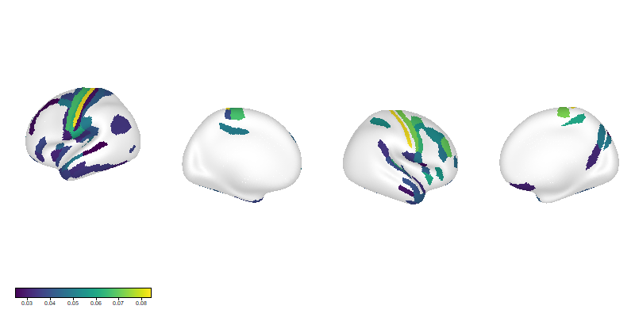

```r
stats.coding.targt %>%
  mutate(beta = ifelse(roi %in% rois.pref.targt.vs.incon, beta, NA)) %>%
  build_overlay("beta") %>%
  plot_surface(underlay = hcp)
```

Test statistics (sum of sign ranks)

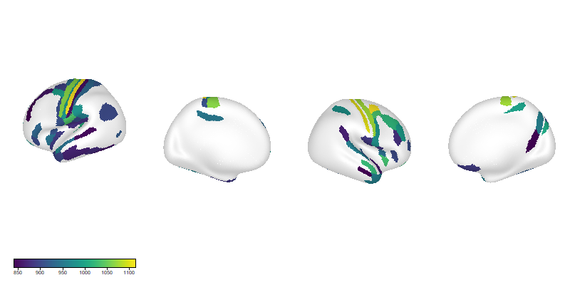

```r
stats.coding.targt %>%
  mutate(v = ifelse(roi %in% rois.pref.targt.vs.incon, v, NA)) %>%
  build_overlay("v") %>%
  plot_surface(underlay = hcp)
```

```r
kable(
  stats.pairs.tdic[roi %in% rois.pref.targt.vs.incon] %>% arrange(-b.targt.incon),
  digits = 2
  )
```

| roi | p.incon.distr | p.targt.distr | p.targt.incon | b.incon.distr | b.targt.distr | b.targt.incon | num.roi | hemi | community | community.short |
| --- | --- | --- | --- | --- | --- | --- | --- | --- | --- | --- |
| 3b_L | 0.93 | 0.00 | 0.00 | 0.01 | 0.09 | 0.08 | 9 | L | somatosensory and motor cortex | M1 and S1 |
| 3a_L | 0.22 | 0.00 | 0.00 | -0.01 | 0.07 | 0.08 | 53 | L | somatosensory and motor cortex | M1 and S1 |
| 4_L | 0.69 | 0.00 | 0.00 | 0.00 | 0.07 | 0.07 | 8 | L | somatosensory and motor cortex | M1 and S1 |
| TE2a_L | 0.70 | 0.02 | 0.01 | -0.01 | 0.04 | 0.05 | 134 | L | lateral temporal cortex | lT |
| V6_R | 0.40 | 0.03 | 0.03 | -0.02 | 0.03 | 0.05 | 183 | R | dorsal stream visual cortex | d vis. |
| A4_R | 0.51 | 0.00 | 0.00 | 0.00 | 0.04 | 0.05 | 355 | R | auditory association cortex | aud. assoc. |
| 43_R | 0.34 | 0.05 | 0.02 | -0.02 | 0.03 | 0.05 | 279 | R | posterior opercular cortex | pOperc |
| 5m_L | 0.51 | 0.03 | 0.03 | -0.01 | 0.04 | 0.05 | 36 | L | paracentral lobular and mid cingulate cortex | PL and mid cing. |
| STSda_L | 0.62 | 0.03 | 0.00 | 0.01 | 0.05 | 0.05 | 128 | L | auditory association cortex | aud. assoc. |
| PFop_L | 0.38 | 0.02 | 0.00 | 0.02 | 0.06 | 0.05 | 147 | L | inferior parietal cortex | iP |
| TE1a_L | 0.94 | 0.08 | 0.00 | 0.00 | 0.04 | 0.04 | 132 | L | lateral temporal cortex | lT |
| TE1a_R | 0.98 | 0.05 | 0.01 | 0.00 | 0.05 | 0.04 | 312 | R | lateral temporal cortex | lT |
| POS2_R | 0.53 | 0.02 | 0.00 | 0.00 | 0.05 | 0.04 | 195 | R | posterior cingulate cortex | pCC |
| 11l_R | 0.40 | 0.01 | 0.01 | -0.01 | 0.03 | 0.04 | 271 | R | orbital and polar frontal cortex | oFC and pFC |
| PBelt_R | 0.81 | 0.03 | 0.01 | 0.01 | 0.05 | 0.04 | 304 | R | early auditory cortex | early aud. |
| STGa_L | 0.39 | 0.01 | 0.02 | -0.01 | 0.03 | 0.04 | 123 | L | auditory association cortex | aud. assoc. |
| STSda_R | 0.87 | 0.06 | 0.00 | 0.00 | 0.04 | 0.04 | 308 | R | auditory association cortex | aud. assoc. |
| V6A_R | 0.35 | 0.06 | 0.01 | 0.00 | 0.04 | 0.04 | 332 | R | dorsal stream visual cortex | d vis. |
| 6v_R | 0.53 | 0.06 | 0.00 | 0.02 | 0.06 | 0.04 | 236 | R | premotor cortex | PM |
| 4_R | 0.59 | 0.13 | 0.01 | 0.02 | 0.05 | 0.04 | 188 | R | somatosensory and motor cortex | M1 and S1 |
| OP4_R | 0.64 | 0.07 | 0.01 | 0.00 | 0.04 | 0.04 | 280 | R | posterior opercular cortex | pOperc |
| 47l_L | 0.39 | 0.07 | 0.04 | -0.01 | 0.03 | 0.03 | 76 | L | inferior frontal cortex | iFC |
| OP2-3_L | 0.46 | 0.03 | 0.04 | -0.01 | 0.03 | 0.03 | 102 | L | posterior opercular cortex | pOperc |
| PoI2_L | 0.59 | 0.17 | 0.01 | 0.01 | 0.05 | 0.03 | 106 | L | insular and frontal opercular cortex | insular and FO |
| TGd_L | 0.88 | 0.19 | 0.03 | 0.00 | 0.04 | 0.03 | 131 | L | lateral temporal cortex | lT |
| 5mv_R | 0.95 | 0.04 | 0.02 | 0.00 | 0.03 | 0.03 | 217 | R | paracentral lobular and mid cingulate cortex | PL and mid cing. |
| 11l_L | 0.67 | 0.02 | 0.02 | -0.01 | 0.03 | 0.03 | 91 | L | orbital and polar frontal cortex | oFC and pFC |
| MBelt_R | 0.65 | 0.07 | 0.00 | 0.01 | 0.05 | 0.03 | 353 | R | early auditory cortex | early aud. |
| TGv_R | 0.61 | 0.03 | 0.03 | 0.00 | 0.03 | 0.03 | 352 | R | lateral temporal cortex | lT |
| PeEc_L | 0.89 | 0.17 | 0.01 | 0.01 | 0.04 | 0.03 | 122 | L | medial temporal cortex | mT |
| TE2p_L | 0.74 | 0.20 | 0.00 | 0.02 | 0.04 | 0.03 | 136 | L | lateral temporal cortex | lT |
| 6v_L | 0.28 | 0.27 | 0.00 | 0.02 | 0.05 | 0.03 | 56 | L | premotor cortex | PM |
| a9-46v_R | 0.50 | 0.14 | 0.00 | 0.02 | 0.05 | 0.03 | 265 | R | dorsolateral prefrontal cortex | dlPFC |
| TGd_R | 0.42 | 0.42 | 0.00 | 0.02 | 0.04 | 0.03 | 311 | R | lateral temporal cortex | lT |
| FEF_R | 0.55 | 0.30 | 0.00 | 0.02 | 0.05 | 0.03 | 190 | R | premotor cortex | PM |
| OFC_R | 0.47 | 0.18 | 0.02 | 0.01 | 0.04 | 0.03 | 273 | R | orbital and polar frontal cortex | oFC and pFC |
| 3b_R | 0.69 | 0.20 | 0.00 | 0.02 | 0.05 | 0.02 | 189 | R | somatosensory and motor cortex | M1 and S1 |
| 23c_L | 0.33 | 0.33 | 0.00 | 0.03 | 0.05 | 0.02 | 38 | L | posterior cingulate cortex | pCC |
| VVC_R | 0.64 | 0.25 | 0.00 | 0.02 | 0.04 | 0.02 | 343 | R | ventral stream visual cortex | v vis. |
| V4t_L | 0.34 | 0.34 | 0.01 | 0.02 | 0.04 | 0.02 | 156 | L | MT+ complex and neighbors | MT+ |
| 7PC_L | 0.41 | 0.38 | 0.00 | 0.02 | 0.04 | 0.02 | 47 | L | superior parietal cortex | sP |
| 9p_L | 0.25 | 0.25 | 0.00 | 0.03 | 0.05 | 0.02 | 71 | L | dorsolateral prefrontal cortex | dlPFC |
| VVC_L | 0.41 | 0.22 | 0.00 | 0.03 | 0.05 | 0.02 | 163 | L | ventral stream visual cortex | v vis. |
| IFSp_R | 0.48 | 0.39 | 0.02 | 0.02 | 0.04 | 0.02 | 261 | R | inferior frontal cortex | iFC |
| p9-46v_R | 0.41 | 0.41 | 0.01 | 0.03 | 0.05 | 0.02 | 263 | R | dorsolateral prefrontal cortex | dlPFC |
| 2_L | 0.17 | 0.35 | 0.00 | 0.04 | 0.05 | 0.02 | 52 | L | somatosensory and motor cortex | M1 and S1 |
| OP4_L | 0.08 | 0.47 | 0.00 | 0.06 | 0.07 | 0.01 | 100 | L | posterior opercular cortex | pOperc |
| p10p_L | 0.06 | 0.36 | 0.00 | 0.03 | 0.05 | 0.01 | 170 | L | orbital and polar frontal cortex | oFC and pFC |
| V8_L | 0.77 | 0.18 | 0.01 | 0.02 | 0.04 | 0.01 | 7 | L | ventral stream visual cortex | v vis. |
| FOP1_R | 0.76 | 0.31 | 0.01 | 0.02 | 0.04 | 0.01 | 293 | R | posterior opercular cortex | pOperc |
| 55b_L | 0.27 | 0.50 | 0.00 | 0.04 | 0.05 | 0.01 | 12 | L | premotor cortex | PM |
| PFcm_L | 0.74 | 0.63 | 0.01 | 0.02 | 0.03 | 0.01 | 105 | L | posterior opercular cortex | pOperc |
| 46_L | 0.46 | 0.30 | 0.00 | 0.02 | 0.04 | 0.01 | 84 | L | dorsolateral prefrontal cortex | dlPFC |
| FOP3_R | 0.62 | 0.43 | 0.01 | 0.02 | 0.03 | 0.01 | 294 | R | insular and frontal opercular cortex | insular and FO |
| FOP5_R | 0.57 | 0.22 | 0.00 | 0.03 | 0.04 | 0.01 | 349 | R | insular and frontal opercular cortex | insular and FO |
| 6d_L | 0.40 | 0.52 | 0.02 | 0.03 | 0.04 | 0.01 | 54 | L | premotor cortex | PM |
| 43_L | 0.63 | 0.63 | 0.03 | 0.01 | 0.03 | 0.01 | 99 | L | posterior opercular cortex | pOperc |
| AIP_R | 0.45 | 0.45 | 0.01 | 0.03 | 0.04 | 0.01 | 297 | R | superior parietal cortex | sP |
| FOP3_L | 0.60 | 0.60 | 0.04 | 0.03 | 0.04 | 0.01 | 114 | L | insular and frontal opercular cortex | insular and FO |
| 55b_R | 0.02 | 0.91 | 0.00 | 0.04 | 0.05 | 0.01 | 192 | R | premotor cortex | PM |
| 8C_R | 0.31 | 0.51 | 0.00 | 0.03 | 0.04 | 0.01 | 253 | R | dorsolateral prefrontal cortex | dlPFC |
| POS1_R | 0.36 | 0.80 | 0.04 | 0.02 | 0.03 | 0.01 | 211 | R | posterior cingulate cortex | pCC |
| MI_L | 0.23 | 0.60 | 0.00 | 0.03 | 0.04 | 0.01 | 109 | L | insular and frontal opercular cortex | insular and FO |
| OP1_L | 0.22 | 0.55 | 0.01 | 0.03 | 0.04 | 0.01 | 101 | L | posterior opercular cortex | pOperc |
| LBelt_L | 0.48 | 0.48 | 0.01 | 0.03 | 0.04 | 0.01 | 174 | L | early auditory cortex | early aud. |
| PSL_R | 0.40 | 0.40 | 0.04 | 0.03 | 0.03 | 0.01 | 205 | R | tempo-parieto-occipital junction | TPOJ |
| 45_L | 0.23 | 0.57 | 0.00 | 0.04 | 0.05 | 0.01 | 75 | L | inferior frontal cortex | iFC |
| FEF_L | 0.39 | 0.42 | 0.00 | 0.04 | 0.05 | 0.01 | 10 | L | premotor cortex | PM |
| PI_R | 0.50 | 0.64 | 0.00 | 0.03 | 0.03 | 0.00 | 358 | R | insular and frontal opercular cortex | insular and FO |
| 1_L | 0.21 | 0.59 | 0.01 | 0.04 | 0.04 | 0.00 | 51 | L | somatosensory and motor cortex | M1 and S1 |
| 8Av_L | 0.28 | 0.61 | 0.02 | 0.03 | 0.04 | 0.00 | 67 | L | dorsolateral prefrontal cortex | dlPFC |
| FFC_L | 0.52 | 0.52 | 0.01 | 0.02 | 0.03 | 0.00 | 18 | L | ventral stream visual cortex | v vis. |
| RI_L | 0.23 | 0.72 | 0.04 | 0.03 | 0.03 | 0.00 | 104 | L | early auditory cortex | early aud. |
| MI_R | 0.28 | 0.82 | 0.00 | 0.04 | 0.04 | 0.00 | 289 | R | insular and frontal opercular cortex | insular and FO |
| PGi_L | 0.42 | 0.69 | 0.01 | 0.04 | 0.04 | 0.00 | 150 | L | inferior parietal cortex | iP |
| STSdp_L | 0.19 | 0.69 | 0.00 | 0.04 | 0.04 | 0.00 | 129 | L | auditory association cortex | aud. assoc. |

#### target > {distractor, conclust, 0} (17 parcels)

Betas

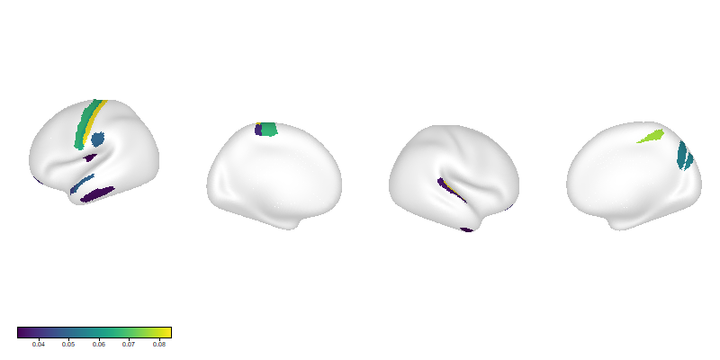

```r
stats.coding.targt %>%
  mutate(beta = ifelse(roi %in% rois.pref.targt, beta, NA)) %>%
  build_overlay("beta") %>%
  plot_surface(underlay = hcp)
```

Test statistics (sum of sign ranks)

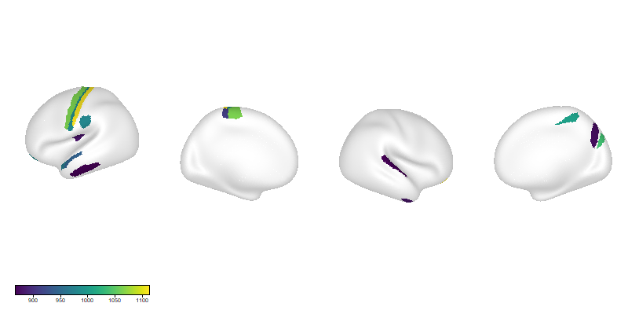

```r
stats.coding.targt %>%
  mutate(v = ifelse(roi %in% rois.pref.targt, v, NA)) %>%
  build_overlay("v") %>%
  plot_surface(underlay = hcp)
```

```r
kable(stats.pairs.tdic[roi %in% rois.pref.targt], digits = 2)
```

| roi | p.incon.distr | p.targt.distr | p.targt.incon | b.incon.distr | b.targt.distr | b.targt.incon | num.roi | hemi | community | community.short |
| --- | --- | --- | --- | --- | --- | --- | --- | --- | --- | --- |
| 11l_L | 0.67 | 0.02 | 0.02 | -0.01 | 0.03 | 0.03 | 91 | L | orbital and polar frontal cortex | oFC and pFC |
| 11l_R | 0.40 | 0.01 | 0.01 | -0.01 | 0.03 | 0.04 | 271 | R | orbital and polar frontal cortex | oFC and pFC |
| 3a_L | 0.22 | 0.00 | 0.00 | -0.01 | 0.07 | 0.08 | 53 | L | somatosensory and motor cortex | M1 and S1 |
| 3b_L | 0.93 | 0.00 | 0.00 | 0.01 | 0.09 | 0.08 | 9 | L | somatosensory and motor cortex | M1 and S1 |
| 4_L | 0.69 | 0.00 | 0.00 | 0.00 | 0.07 | 0.07 | 8 | L | somatosensory and motor cortex | M1 and S1 |
| 5m_L | 0.51 | 0.03 | 0.03 | -0.01 | 0.04 | 0.05 | 36 | L | paracentral lobular and mid cingulate cortex | PL and mid cing. |
| 5mv_R | 0.95 | 0.04 | 0.02 | 0.00 | 0.03 | 0.03 | 217 | R | paracentral lobular and mid cingulate cortex | PL and mid cing. |
| A4_R | 0.51 | 0.00 | 0.00 | 0.00 | 0.04 | 0.05 | 355 | R | auditory association cortex | aud. assoc. |
| OP2-3_L | 0.46 | 0.03 | 0.04 | -0.01 | 0.03 | 0.03 | 102 | L | posterior opercular cortex | pOperc |
| PBelt_R | 0.81 | 0.03 | 0.01 | 0.01 | 0.05 | 0.04 | 304 | R | early auditory cortex | early aud. |
| PFop_L | 0.38 | 0.02 | 0.00 | 0.02 | 0.06 | 0.05 | 147 | L | inferior parietal cortex | iP |
| POS2_R | 0.53 | 0.02 | 0.00 | 0.00 | 0.05 | 0.04 | 195 | R | posterior cingulate cortex | pCC |
| STGa_L | 0.39 | 0.01 | 0.02 | -0.01 | 0.03 | 0.04 | 123 | L | auditory association cortex | aud. assoc. |
| STSda_L | 0.62 | 0.03 | 0.00 | 0.01 | 0.05 | 0.05 | 128 | L | auditory association cortex | aud. assoc. |
| TE2a_L | 0.70 | 0.02 | 0.01 | -0.01 | 0.04 | 0.05 | 134 | L | lateral temporal cortex | lT |
| TGv_R | 0.61 | 0.03 | 0.03 | 0.00 | 0.03 | 0.03 | 352 | R | lateral temporal cortex | lT |
| V6_R | 0.40 | 0.03 | 0.03 | -0.02 | 0.03 | 0.05 | 183 | R | dorsal stream visual cortex | d vis. |

### distractor

#### distractor > {target, 0} (0 parcels)

```r
kable(
  stats.pairs.tdic[roi %in% rois.pref.distr.vs.targt] %>% arrange(b.targt.distr),
  digits = 2
  )
```

| roi | p.incon.distr | p.targt.distr | p.targt.incon | b.incon.distr | b.targt.distr | b.targt.incon | num.roi | hemi | community | community.short |
| --- | --- | --- | --- | --- | --- | --- | --- | --- | --- | --- |

#### distractor > {conclust, 0}(3 parcels)

```r
kable(
  stats.pairs.tdic[roi %in% rois.pref.distr.vs.incon] %>% arrange(b.incon.distr),
  digits = 2
  )
```

| roi | p.incon.distr | p.targt.distr | p.targt.incon | b.incon.distr | b.targt.distr | b.targt.incon | num.roi | hemi | community | community.short |
| --- | --- | --- | --- | --- | --- | --- | --- | --- | --- | --- |
| V2_L | 0.75 | 0.75 | 0.69 | -0.01 | -0.02 | -0.01 | 4 | L | early visual cortex | early vis. |
| V7_L | 0.95 | 0.84 | 0.50 | 0.00 | 0.01 | 0.01 | 16 | L | dorsal stream visual cortex | d vis. |
| V1_L | 0.49 | 0.36 | 0.12 | 0.00 | -0.03 | -0.03 | 1 | L | primary visual cortex | V1 |

#### distractor > {target, conclust, 0}

No parcels meet criteria (no parcels distractor > target).

### conclust

##### conclust > {distractor, 0} (22 parcels)

Betas

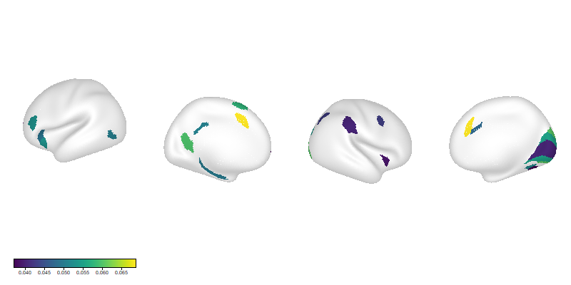

```r
stats.coding.incon  %>%
  mutate(beta = ifelse(roi %in% rois.pref.incon.vs.distr, beta, NA)) %>%
  build_overlay("beta") %>%
  plot_surface(underlay = hcp)
```

Test statistics (sum of sign ranks)

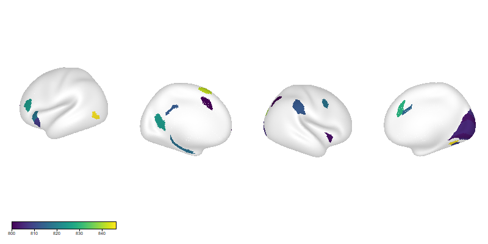

```r
stats.coding.incon  %>%
  mutate(v = ifelse(roi %in% rois.pref.incon.vs.distr, v, NA)) %>%
  build_overlay("v") %>%
  plot_surface(underlay = hcp)
```

```r
kable(
  stats.pairs.tdic[roi %in% rois.pref.incon.vs.distr] %>% arrange(-b.incon.distr),
  digits = 2
  )
```

| roi | p.incon.distr | p.targt.distr | p.targt.incon | b.incon.distr | b.targt.distr | b.targt.incon | num.roi | hemi | community | community.short |
| --- | --- | --- | --- | --- | --- | --- | --- | --- | --- | --- |
| p32pr_L | 0.50 | 0.50 | 0.50 | 0.05 | 0.01 | -0.04 | 60 | L | anterior cingulate and medial prefrontal cortex | aCC and mPFC |
| a32pr_R | 0.15 | 0.41 | 0.11 | 0.05 | 0.02 | -0.03 | 359 | R | anterior cingulate and medial prefrontal cortex | aCC and mPFC |
| VMV2_R | 0.09 | 0.41 | 0.19 | 0.05 | 0.02 | -0.03 | 340 | R | ventral stream visual cortex | v vis. |
| d23ab_L | 0.20 | 0.38 | 0.26 | 0.05 | 0.02 | -0.03 | 34 | L | posterior cingulate cortex | pCC |
| PF_R | 0.10 | 0.53 | 0.10 | 0.05 | 0.03 | -0.02 | 328 | R | inferior parietal cortex | iP |
| POS1_L | 0.27 | 0.36 | 0.36 | 0.05 | 0.01 | -0.04 | 31 | L | posterior cingulate cortex | pCC |
| AVI_L | 0.12 | 0.69 | 0.05 | 0.04 | 0.03 | -0.02 | 111 | L | insular and frontal opercular cortex | insular and FO |
| a24pr_R | 0.19 | 0.50 | 0.17 | 0.04 | 0.02 | -0.02 | 239 | R | anterior cingulate and medial prefrontal cortex | aCC and mPFC |
| MI_R | 0.28 | 0.82 | 0.00 | 0.04 | 0.04 | 0.00 | 289 | R | insular and frontal opercular cortex | insular and FO |
| H_L | 0.36 | 0.36 | 0.36 | 0.04 | 0.02 | -0.02 | 120 | L | medial temporal cortex | mT |
| V3B_R | 0.25 | 0.25 | 0.68 | 0.04 | 0.01 | -0.03 | 199 | R | dorsal stream visual cortex | d vis. |
| SFL_L | 0.13 | 0.41 | 0.13 | 0.04 | 0.02 | -0.01 | 26 | L | dorsolateral prefrontal cortex | dlPFC |
| IFSa_L | 0.40 | 0.40 | 0.40 | 0.04 | 0.01 | -0.03 | 82 | L | inferior frontal cortex | iFC |
| FOP5_L | 0.35 | 0.92 | 0.08 | 0.03 | 0.03 | 0.00 | 169 | L | insular and frontal opercular cortex | insular and FO |
| PEF_R | 0.59 | 0.59 | 0.59 | 0.03 | 0.02 | -0.02 | 191 | R | premotor cortex | PM |
| p10p_L | 0.06 | 0.36 | 0.00 | 0.03 | 0.05 | 0.01 | 170 | L | orbital and polar frontal cortex | oFC and pFC |
| V3_R | 0.53 | 0.53 | 0.53 | 0.03 | -0.01 | -0.04 | 185 | R | early visual cortex | early vis. |
| VMV3_R | 0.33 | 0.76 | 0.33 | 0.03 | 0.01 | -0.01 | 334 | R | ventral stream visual cortex | v vis. |
| IP1_R | 0.56 | 0.56 | 0.44 | 0.03 | 0.02 | -0.01 | 325 | R | inferior parietal cortex | iP |
| FST_L | 0.70 | 0.70 | 0.70 | 0.02 | 0.01 | -0.01 | 157 | L | MT+ complex and neighbors | MT+ |
| V2_R | 0.65 | 0.65 | 0.65 | 0.02 | -0.01 | -0.03 | 184 | R | early visual cortex | early vis. |
| V1_R | 0.89 | 0.37 | 0.37 | 0.01 | -0.02 | -0.03 | 181 | R | primary visual cortex | V1 |

##### conclust > {target, 0} (19 parcels)

Betas

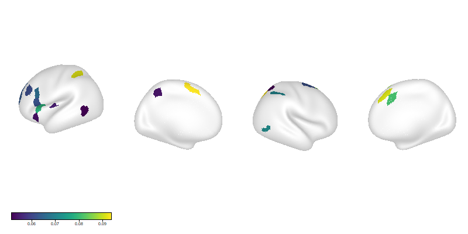

```r
stats.coding.incon  %>%
  mutate(beta = ifelse(roi %in% rois.pref.incon.vs.targt, beta, NA)) %>%
  build_overlay("beta") %>%
  plot_surface(underlay = hcp)
```

Test statistics (sum of sign ranks)

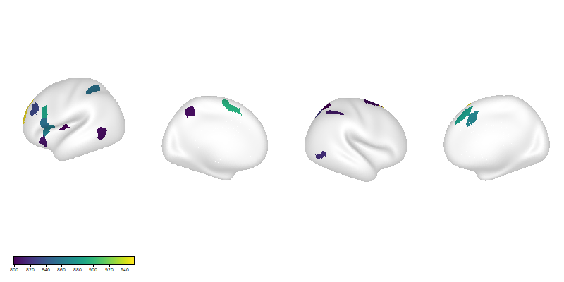

```r
stats.coding.incon  %>%
  mutate(v = ifelse(roi %in% rois.pref.incon.vs.targt, v, NA)) %>%
  build_overlay("v") %>%
  plot_surface(underlay = hcp)
```

```r
kable(
  stats.pairs.tdic[roi %in% rois.pref.incon.vs.targt] %>% arrange(b.targt.incon),
  digits = 2
  )
```

| roi | p.incon.distr | p.targt.distr | p.targt.incon | b.incon.distr | b.targt.distr | b.targt.incon | num.roi | hemi | community | community.short |
| --- | --- | --- | --- | --- | --- | --- | --- | --- | --- | --- |
| MIP_R | 0.01 | 0.09 | 0.03 | 0.09 | 0.03 | -0.06 | 230 | R | superior parietal cortex | sP |
| 9-46d_L | 0.00 | 0.00 | 0.03 | 0.08 | 0.03 | -0.05 | 86 | L | dorsolateral prefrontal cortex | dlPFC |
| SCEF_L | 0.01 | 0.11 | 0.01 | 0.08 | 0.03 | -0.05 | 43 | L | paracentral lobular and mid cingulate cortex | PL and mid cing. |
| AIP_L | 0.01 | 0.51 | 0.01 | 0.09 | 0.04 | -0.05 | 117 | L | superior parietal cortex | sP |
| s6-8_R | 0.00 | 0.02 | 0.02 | 0.08 | 0.03 | -0.05 | 278 | R | dorsolateral prefrontal cortex | dlPFC |
| FOP4_L | 0.02 | 0.09 | 0.01 | 0.07 | 0.03 | -0.05 | 108 | L | insular and frontal opercular cortex | insular and FO |
| 44_L | 0.00 | 0.18 | 0.00 | 0.07 | 0.04 | -0.04 | 74 | L | inferior frontal cortex | iFC |
| p32pr_R | 0.01 | 0.23 | 0.00 | 0.07 | 0.04 | -0.03 | 240 | R | anterior cingulate and medial prefrontal cortex | aCC and mPFC |
| 8BM_R | 0.00 | 0.61 | 0.00 | 0.08 | 0.05 | -0.03 | 243 | R | anterior cingulate and medial prefrontal cortex | aCC and mPFC |
| PCV_L | 0.02 | 0.32 | 0.02 | 0.06 | 0.04 | -0.03 | 27 | L | posterior cingulate cortex | pCC |
| IFJa_L | 0.03 | 0.19 | 0.03 | 0.06 | 0.04 | -0.03 | 79 | L | inferior frontal cortex | iFC |
| 6a_R | 0.04 | 0.68 | 0.04 | 0.06 | 0.03 | -0.03 | 276 | R | premotor cortex | PM |
| IP2_R | 0.00 | 0.45 | 0.00 | 0.07 | 0.05 | -0.03 | 324 | R | inferior parietal cortex | iP |
| FST_R | 0.05 | 0.43 | 0.05 | 0.06 | 0.03 | -0.02 | 337 | R | MT+ complex and neighbors | MT+ |
| p9-46v_L | 0.00 | 0.57 | 0.00 | 0.07 | 0.05 | -0.02 | 83 | L | dorsolateral prefrontal cortex | dlPFC |
| PHT_L | 0.07 | 0.48 | 0.04 | 0.05 | 0.03 | -0.02 | 137 | L | lateral temporal cortex | lT |
| AVI_L | 0.12 | 0.69 | 0.05 | 0.04 | 0.03 | -0.02 | 111 | L | insular and frontal opercular cortex | insular and FO |
| LIPv_R | 0.05 | 0.66 | 0.05 | 0.05 | 0.04 | -0.01 | 228 | R | superior parietal cortex | sP |
| Ig_L | 0.09 | 0.81 | 0.01 | 0.06 | 0.04 | -0.01 | 168 | L | insular and frontal opercular cortex | insular and FO |

```r
kable(
  stats.pairs.tdic[roi %in% rois.pref.incon],
  digits = 2
  )
```

| roi | p.incon.distr | p.targt.distr | p.targt.incon | b.incon.distr | b.targt.distr | b.targt.incon | num.roi | hemi | community | community.short |
| --- | --- | --- | --- | --- | --- | --- | --- | --- | --- | --- |
| AVI_L | 0.12 | 0.69 | 0.05 | 0.04 | 0.03 | -0.02 | 111 | L | insular and frontal opercular cortex | insular and FO |

### intersections

```r
intersect(rois.pref.incon.vs.distr, rois.pref.targt.vs.distr)
```

```
## character(0)
```

```r
intersect(rois.pref.targt.vs.incon, rois.pref.distr.vs.incon)
```

```
## character(0)
```

```r
intersect(rois.pref.incon.vs.distr, rois.pref.distr.vs.targt)
```

```
## character(0)
```

# 3. **selectivity analysis**: equivalence testing

Here I establish which (if any) ROIs previously identified as having a *preference* for a task dimension(s), are *selective* for said task dimension(s). Establishing selectivity involves “confirming the null”: e.g., “this ROI was only coding for target information, not distractor or conclust”. To perform such a test of equivalence, I use the two-one sided significance testing procedure (TOST).

Given an effect size $\Delta$, the TOST requires specifiying two criteria: an $\alpha$, and a smallest effect size of interest, $\Delta_U$. In TOST, two one-sided tests are performed: $H_1: \Delta \geq -\Delta_U$ and $H_2: \Delta \leq \Delta_U$. Note that the null hypothesis in each of these tests is the *presence* of an effect. Thus, if both are rejected (p-values are $< \alpha$), the test provides positive evidence for the absence of a “meaningful” effect size. TOST is the frequentist’s alternative to bayesian analysis.

In the absence of an a priori effect size of interest, I use a simulated one. Given $\alpha = 0.05$, $N = 49$, and assuming gaussian error, I simulate the smallest effect size observable via wilcoxon signed-rank under the deisred power level of $1 - \beta = 0.8$.

```r
fname.es <- here("analyses", "coding_profiles", "smallest-effect-size-of-interest.csv")

if (!file.exists(fname.es)) {

  powersim <- function(es, n = 49, a = 0.05, nsim = 5000) {

    out <- numeric(nsim)

    for (sim.i in seq_len(nsim)) {
      x <- rnorm(n, es)
      p <- wilcox.test(x, alternative = "greater")$p.value
      out[sim.i] <- p < a
    }

    sum(out) / nsim

  }

  es <- seq(0, 0.5, 0.001)  ## range of effect sizes to simulate

  n.cores <- detectCores()
  cl <- makeCluster(n.cores - 1)
  registerDoParallel(cl)
  res <- foreach(ii = es, .combine = c) %dopar% {
    set.seed(ii * 1000)  ## set seed anew each iteraion (on each worker)
    powersim(ii)  ## power
  }
  stopCluster(cl)

  plot(es, res, main = "effect size (cohen's d) by power level of signed rank")

  sesoi <- data.frame(effect.size = es, hit.rate = res)

  write.csv(sesoi, here("analyses", "coding_profiles", "smallest-effect-size-of-interest.csv"), row.names = FALSE)

} else {

  sesoi <- read.csv(here("analyses", "coding_profiles", "smallest-effect-size-of-interest.csv"))
  # sesoi8 <- min(sesoi$effect.size[sesoi$hit.rate >= 0.8])  ## minimum effect size detectable at 0.8 power

}

## fit loess to generate smooth predicted values:
fit <- loess.as(sesoi$hit.rate, sesoi$effect.size)  ## uses model selection procedure to select optimal smoothing param

plot(sesoi$hit.rate, sesoi$effect.size)
lines(sesoi$hit.rate, fit$fitted, col = "firebrick")
```

[figure not shown]

```r
(sesoi8 <- predict(fit, 0.8))  ## minimum effect size of interest
```

```
## [1] 0.3702
```

Now this minimum effect size serves as the reference (null) value in two non-central sign-rank tests. Note that I use the standardized betas (divisively normalized by their standard deviation) to conduct this test (this puts the model fits / betas in the same unit as the reference effect size).

```r
stats.tosts <- stats.subjs.tdic %>%
  filter(param %in% params.interest) %>%
  group_by(param, roi) %>%
  summarize(
    du = wilcox.test(beta / sd(beta), alternative = "less", mu = sesoi8)$p.value,  ## less than upward bound?
    dl = wilcox.test(beta / sd(beta), alternative = "greater", mu = -sesoi8)$p.value,  ## greater than lower bound?
    p = max(du, dl)  ## take largest p-value
  ) %>%
  as.data.table
```

## target

### target > {distractor, 0} & distractor ~ 0

Establish absence of **distractor** coding:

```r
rois.tost.targt.vs.distr <- stats.tosts[roi %in% rois.pref.targt.vs.distr & param == "distractor", ] %>%
  ungroup %>%
  mutate(p.fdr = p.adjust(p, method = "fdr"), p.holm = p.adjust(p, method = "holm")) %>%
  filter(p.fdr < 0.05) %>%
  .$roi

stats.tosts[param == "distractor" & roi %in% rois.tost.targt.vs.distr]
```

```
## Empty data.table (0 rows and 5 cols): param,roi,du,dl,p
```

### target > {conclust, 0} & conclust ~ 0

Establish absence of **conclust** coding:

```r
rois.tost.targt.vs.incon <- stats.tosts[roi %in% rois.pref.targt.vs.incon & param == "conclust", ] %>%
  ungroup %>%
  mutate(p.fdr = p.adjust(p, method = "fdr"), p.holm = p.adjust(p, method = "holm")) %>%
  filter(p.fdr < 0.05) %>%
  .$roi


stats.tosts[param == "conclust" & roi %in% rois.tost.targt.vs.incon]
```

```
## Empty data.table (0 rows and 5 cols): param,roi,du,dl,p
```

### target > {conclust, distractor, 0} & {conclust, distractor} ~ 0

The intersection of those sets:

none

## distractor

### distractor > {target, 0} & target ~ 0

None with preference for distractor.

### distractor > {conclust, 0} & conclust ~ 0

Establish absence of **conclust** coding:

```r
rois.tost.distr.vs.incon <- stats.tosts[roi %in% rois.pref.distr.vs.incon & param == "conclust", ] %>%
  ungroup %>%
  mutate(p.fdr = p.adjust(p, method = "fdr"), p.holm = p.adjust(p, method = "holm")) %>%
  filter(p.fdr < 0.05) %>%
  .$roi


stats.tosts[param == "conclust" & roi %in% rois.tost.distr.vs.incon]
```

```
## Empty data.table (0 rows and 5 cols): param,roi,du,dl,p
```

### distractor > {conclust, distractor, 0} & {conclust, distractor} ~ 0

The intersection of those sets:

None.

## conclust

### conclust > {distractor, 0} & distractor ~ 0

Establish absence of **distractor** coding:

```r
rois.tost.incon.vs.distr <- stats.tosts[roi %in% rois.pref.incon.vs.distr & param == "distractor", ] %>%
  ungroup %>%
  mutate(p.fdr = p.adjust(p, method = "fdr"), p.holm = p.adjust(p, method = "holm")) %>%
  filter(p.fdr < 0.05) %>%
  .$roi

stats.tosts[param == "distractor" & roi %in% rois.tost.incon.vs.distr]
```

```
## Empty data.table (0 rows and 5 cols): param,roi,du,dl,p
```

### conclust > {target, 0} & target ~ 0

Establish absence of **target** coding:

```r
rois.tost.incon.vs.targt <- stats.tosts[roi %in% rois.pref.incon.vs.targt & param == "target", ] %>%
  ungroup %>%
  mutate(p.fdr = p.adjust(p, method = "fdr"), p.holm = p.adjust(p, method = "holm")) %>%
  filter(p.fdr < 0.05) %>%
  .$roi


stats.tosts[param == "target" & roi %in% rois.tost.incon.vs.targt]
```

```
## Empty data.table (0 rows and 5 cols): param,roi,du,dl,p
```

### conclust > {target, distractor, 0} & {target, distractor} ~ 0

The intersection of those sets:

None.